# Elaborato per Laboratorio di R

Preparazione dati

Manuel Moscariello

4/19/2020

Di seguito espongo come sono arrivato dall’esportazione in JSON di tutte le attività su Telegram al dataset utilizzato per le analisi.

Visto che probabilmente la gente non vuol far sapere che se la fa con me, i nomi sono stati sostituiti da pseudonimi.

Il file Rmd è scaricabile qui

```r
knitr::opts_chunk$set(warning=FALSE, message=FALSE)
```

```r
# Importiamo tutte le librerie necessarie

library(jsonlite)
library(lubridate)
library(tidyverse)
library(purrr)
```

Con `str(rawTelegram)` vediamo che questo file JSON è una lista, di 3 elementi. Nel primo ci sono dati generali, negli altri due ci sono tutte le conversazioni di gruppo. Ogni elemento della lista è un dataframe, che a sua volta contiene liste e data frame. Estraiamo e riagliamo fino ad avere solo quello che interessa a noi, il data frame della chat

```r
rawTG<-fromJSON("result.json")

TG01<- chuck(rawTG, 2, 2)

TG01<-TG01[1,]

TG01 <- chuck(TG01, 4)

TG01<-TG01[[1]]

# Trasformiamo in una tibble
TG01 <- as_tibble(TG01)

# eliminiamo tutti i partecipanti che hanno scritto meno di 20 messaggi(sono solo 2)


TG02<-group_by(TG01, from) %>%
  filter(n()> 20) %>%
  ungroup()

colnames(TG02)[which(names(TG02) == "from")] <- "author"

# Rimuoviamo i messaggi di sistema (NA)

TG02 <- filter(TG02,
               !is.na(author))

# Campio anche il mio nick per allinearlo con gli altri (è più estetica che altro)

TG02$author[which(TG02$author == "arteteco")] <- "Psilocybe"

# Eliminiamo le colonne compromettenti

TG03<-select(TG02, -from_id, -actor, -forwarded_from, -actor_id, -location_information)
```

E ora rimane un ultima cosa da fare, sistemare il **contenuto dei messaggi**, nella colonna `text`. Esploriamolo e vediamo come raccogliere il più possibile

```r
# La colonna sarà ovviamente una lista, ma di cosa sarà fatta la lista? Sarà omogenea per data type?


textDataType <-c()

for (i in 1:nrow(TG03)) {
  tmp <- class(chuck(TG03$text, i))
  textDataType<-c(textDataType, tmp)
}


unique(textDataType)
```

```
## [1] "character"  "list"       "data.frame"
```

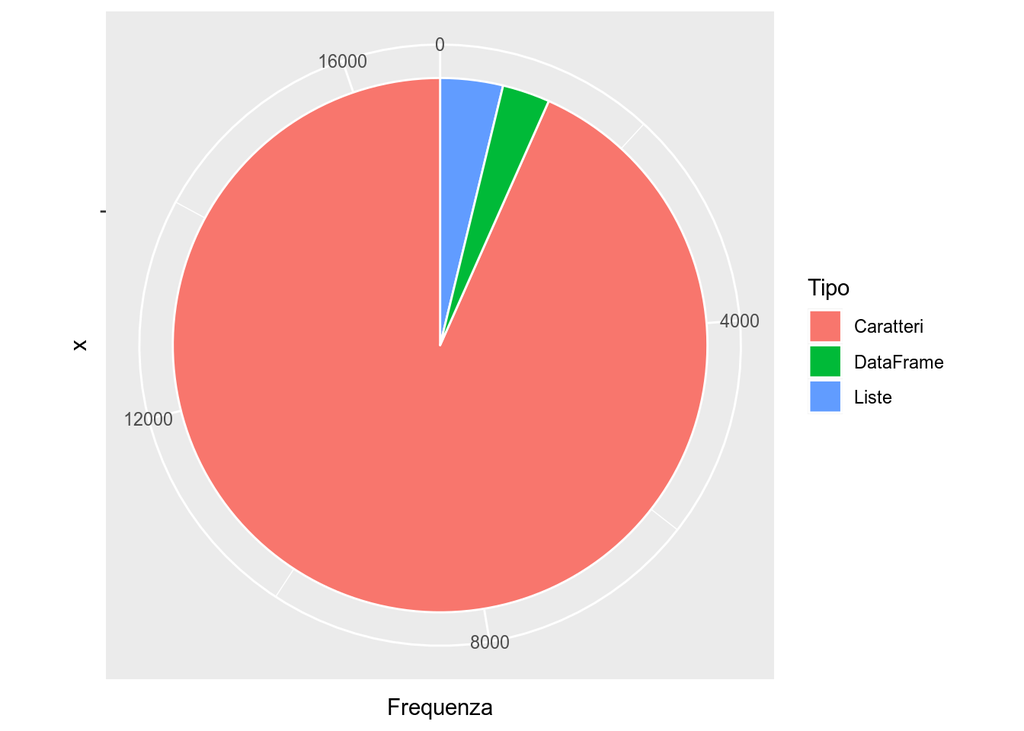

```r
# Abbiamo una lista che talvolta ha caratteri, talvolta liste, talvolta data frame.
# Quando sono caratteri dovrebbero essere semplice testo. Ma data frame e liste per cosa sono?


textLists<-c()
textChar<-c()
textDf<-c()

for (i in 1:nrow(TG03)) {
  tmpID<-chuck(TG03$text, i)
  tmp <- class(tmpID)

  if(tmp == "list"){
  textLists<-c(textLists, tmpID)
  }

  else if(tmp == "character"){
    textChar<-c(textChar, tmpID)
  }

  else if(tmp == "data.frame"){
    textDf<-c(textDf, tmpID)
  }
}

# I messaggi più comuni sono, per fortuna, quelli in caratteri mentre le liste e i data frame hanno un'importanza più marginale


textLength <- tribble(
  ~Tipo,         ~Frequenza,
  "Liste",      length(textLists),
  "Caratteri",  length(textChar),
  "DataFrame",  length(textDf)
)

textLength <- mutate(textLength, prop = Frequenza/sum(textLength$Frequenza))

ggplot(textLength, aes(x="", y=Frequenza, fill=Tipo))+
  geom_bar(width = 1, stat = "identity", color="white")+
  coord_polar("y", start=0)
```

```r
# Esploriamo i casi in cui gli oggetti della colonna sono liste

# Che oggetti contengono queste liste?

textListsDataType<-c()
for (i in 1:length(textLists)) {
  tmp <- class(chuck(textLists, i))
  textListsDataType<-c(textListsDataType, tmp)
}

unique(textListsDataType)
```

```
## [1] "list"      "character"
```

```r
# A volte sono liste di liste, altre volte liste di caratteri. Vediamo come sono fatti entrambi ricilando il codice di sopra

textListsChar<-c()
textListsLists<-c()
for (i in 1:length(textLists)) {
  tmpID<-chuck(textLists, i)
  tmp <- class(tmpID)

  if(tmp == "list"){
  textListsLists<-c(textListsLists, tmpID)
  }

  else if(tmp == "character"){
    textListsChar<-c(textListsChar, tmpID)
  }

}
```

- Quando la classe è `character` sono praticamente messaggi normali, e possiamo trattarli come tali (sostituendo “a” ad ogni lettera)
- Quando invece la classe è una lista sono link, hashtag e citazioni. Essendo pochi oggetti comunque rispetto a tutto e per i fini dell’esercizio possiamo trattarli come char e sostituire tutti i contenuti con una stringa vuota ""

Per ultimo vediamo il caso in cui siano `data frame`. Anche qui si tratta di link e di testi ma sono strutturati come tabella per qualche motivo. Nessun messaggio testuale, possiamo sostituire ogni campo con una stringa vuota `""`

Procediamo ad apportare tutte le modifiche:

```r
for (i in 1:nrow(TG03)) {
  tmpID<-chuck(TG03$text, i)
  tmp <- class(tmpID)

  if(tmp == "list"){
    TG03$text[i]<-""
  }

  else if(tmp == "character"){
    TG03$text[i]<-str_replace_all(textChar[i], "[a-z,A-Z,0-9]", "a")
  }

  else if(tmp == "data.frame"){
    TG03$text[i]<-""
  }
}

# Controlliamo che tutto sia andato a buon fine. Dovremmo avere 0 liste e 0 data frame.

textLists<-c()
textChar<-c()
textDf<-c()

for (i in 1:nrow(TG03)) {
  tmpID<-chuck(TG03$text, i)
  tmp <- class(tmpID)

  if(tmp == "list"){
  textLists<-c(textLists, tmpID)
  }

  else if(tmp == "character"){
    textChar<-c(textChar, tmpID)
  }

  else if(tmp == "data.frame"){
    textDf<-c(textDf, tmpID)
  }
}

length(textChar)
```

```
## [1] 16257
```

```r
length(textLists)
```

```
## [1] 0
```

```r
length(textDf)
```

```
## [1] 0
```

```r
# Ed esporto il dataset, ancora grezzo ma innocuo

exportJSON <- toJSON(TG03, pretty = TRUE)
write(exportJSON, "dataTG.json")
```